# Introduction to `farsdata` Package

[®γσ, Lian Hu](https://englianhu.github.io/) ®

2018-11-09

This package is primarily built for educational purposes. The package enables one to explore fatal traffic accidents from 2013-2015 using data from the National Highway Traffic Safety Administration (NHTSA) Fatality Analysis Reporting System (FARS).

## The Data

The data in this package come from the National Highway Traffic Safety Administration (NHTSA) Fatality Analysis Reporting System (FARS) data.

```r
fars_2013_fn <- make_filename(2013)
fars_2013 <- fars_read(fars_2013_fn)
dim(fars_2013)
```

```
## [1] 30202    50
```

```r
fars_2013
```

```
## # A tibble: 30,202 x 50
##    STATE ST_CASE VE_TOTAL VE_FORMS PVH_INVL  PEDS PERNOTMVIT PERMVIT
##    <int>   <int>    <int>    <int>    <int> <int>      <int>   <int>
##  1     1   10001        1        1        0     0          0       8
##  2     1   10002        2        2        0     0          0       2
##  3     1   10003        1        1        0     0          0       1
##  4     1   10004        1        1        0     0          0       3
##  5     1   10005        2        2        0     0          0       3
##  6     1   10006        2        2        0     0          0       3
##  7     1   10007        1        1        0     0          0       1
##  8     1   10008        2        2        0     0          0       2
##  9     1   10009        1        1        0     0          0       1
## 10     1   10010        2        2        0     0          0       4
## # ... with 30,192 more rows, and 42 more variables: PERSONS <int>,
## #   COUNTY <int>, CITY <int>, DAY <int>, MONTH <int>, YEAR <int>,
## #   DAY_WEEK <int>, HOUR <int>, MINUTE <int>, NHS <int>, ROAD_FNC <int>,
## #   ROUTE <int>, TWAY_ID <chr>, TWAY_ID2 <chr>, MILEPT <int>,
## #   LATITUDE <dbl>, LONGITUD <dbl>, SP_JUR <int>, HARM_EV <int>,
## #   MAN_COLL <int>, RELJCT1 <int>, RELJCT2 <int>, TYP_INT <int>,
## #   WRK_ZONE <int>, REL_ROAD <int>, LGT_COND <int>, WEATHER1 <int>,
## #   WEATHER2 <int>, WEATHER <int>, SCH_BUS <int>, RAIL <chr>,
## #   NOT_HOUR <int>, NOT_MIN <int>, ARR_HOUR <int>, ARR_MIN <int>,
## #   HOSP_HR <int>, HOSP_MN <int>, CF1 <int>, CF2 <int>, CF3 <int>,
## #   FATALS <int>, DRUNK_DR <int>
```

For detailed information about the data, see the [NHTSA FARS Manuals & Documentation page](https://crashstats.nhtsa.dot.gov/#/DocumentTypeList/4).

## Loading FARS Data

To load all of the data for a given year, use the `make_filename()` and `fars_read()` functions, as shown in the previous section.

### About the Filename

Use the `make_filename` command to find out where data is stored on your machine and/or create a filename to save/load new data.

BEWARE: re-installing the package may cause your data to be overridden

```r
fars_2013_fn <- make_filename(2013)
fars_2013_fn
```

```
## [1] "C:/Users/Owner/Documents/R/win-library/3.5/farsdata/extdata/accident_2013.csv.bz2"
```

### Single Year

If you wish to just look at fatality data for a a single year, use the `fars_read_years()` function with a single year as input. The only data columns selected are `MONTH` and `year`. This returns a list of length one, and the first element in the list is the `tbl_df` (the `tidyverse` data frame) listing the month and year for each fatal accident.

```r
fars_2014 <- fars_read_years(years = 2014)
fars_2014[[1]]
```

```
## # A tibble: 30,056 x 2
##    MONTH  year
##    <int> <int>
##  1     1  2014
##  2     1  2014
##  3     1  2014
##  4     1  2014
##  5     1  2014
##  6     1  2014
##  7     1  2014
##  8     1  2014
##  9     1  2014
## 10     1  2014
## # ... with 30,046 more rows
```

### Multiple Years

If you wish to look at fatalities for multiple years, enter a vector of years as the argument for the `fars_read_years()` function (examples: `fars_read_years(years = c(2013, 2015))` or `fars_read_years(2013:2015)`. Again, this returns a list of `tbl_df`s, with each element of the list showing the month and year for each fatality.

```r
fars_3yrs <- fars_read_years(years = 2013:2015)
fars_3yrs
```

```
## [[1]]
## # A tibble: 30,202 x 2
##    MONTH  year
##    <int> <int>
##  1     1  2013
##  2     1  2013
##  3     1  2013
##  4     1  2013
##  5     1  2013
##  6     1  2013
##  7     1  2013
##  8     1  2013
##  9     1  2013
## 10     1  2013
## # ... with 30,192 more rows
##
## [[2]]
## # A tibble: 30,056 x 2
##    MONTH  year
##    <int> <int>
##  1     1  2014
##  2     1  2014
##  3     1  2014
##  4     1  2014
##  5     1  2014
##  6     1  2014
##  7     1  2014
##  8     1  2014
##  9     1  2014
## 10     1  2014
## # ... with 30,046 more rows
##
## [[3]]
## # A tibble: 32,166 x 2
##    MONTH  year
##    <int> <int>
##  1     1  2015
##  2     1  2015
##  3     1  2015
##  4     1  2015
##  5     1  2015
##  6     1  2015
##  7     1  2015
##  8     1  2015
##  9     1  2015
## 10     1  2015
## # ... with 32,156 more rows
```

## Summarizing FARS Data

The `fars_summarize_years()` function take the same argument as the `fars_read_years()`, and produces a summary of the simple counts of fatalities by month and year:

```r
fars_summary <- fars_summarize_years(2013:2015)
fars_summary
```

```
## # A tibble: 12 x 4
##    MONTH `2013` `2014` `2015`
##    <int>  <int>  <int>  <int>
##  1     1   2230   2168   2368
##  2     2   1952   1893   1968
##  3     3   2356   2245   2385
##  4     4   2300   2308   2430
##  5     5   2532   2596   2847
##  6     6   2692   2583   2765
##  7     7   2660   2696   2998
##  8     8   2899   2800   3016
##  9     9   2741   2618   2865
## 10    10   2768   2831   3019
## 11    11   2615   2714   2724
## 12    12   2457   2604   2781
```

## Mapping Fatal Crashes

Finally, the `fars_map_state` function takes a state ID number and a year, and maps that state’s fatalities with a dot at the fatality location. Note that in order to use this function, you will likely need to load the `mapdata` package.

For a list of the state ID numbers, see page 26 of the [FARS Analytical User’s Guide (2015)](https://crashstats.nhtsa.dot.gov/Api/Public/ViewPublication/812315#27).

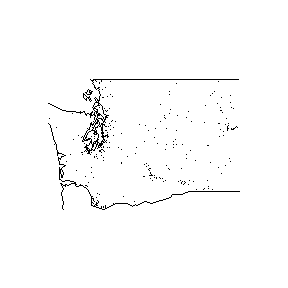

```r
fars_map_state(53, 2014)
```

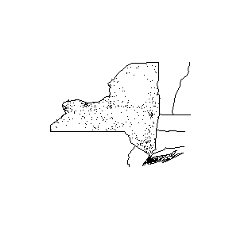

```r
fars_map_state(36, 2014)
```

# Introduction to `farsdata` Package

[®γσ, Lian Hu](https://englianhu.github.io/) ®

2018-11-09

This package is primarily built for educational purposes. The package enables one to explore fatal traffic accidents from 2013-2015 using data from the National Highway Traffic Safety Administration (NHTSA) Fatality Analysis Reporting System (FARS).

## The Data

The data in this package come from the National Highway Traffic Safety Administration (NHTSA) Fatality Analysis Reporting System (FARS) data.

```r
fars_2013_fn <- make_filename(2013)
fars_2013 <- fars_read(fars_2013_fn)
dim(fars_2013)
```

```
## [1] 30202    50
```

```r
fars_2013
```

```
## # A tibble: 30,202 x 50
##    STATE ST_CASE VE_TOTAL VE_FORMS PVH_INVL  PEDS PERNOTMVIT PERMVIT
##    <int>   <int>    <int>    <int>    <int> <int>      <int>   <int>
##  1     1   10001        1        1        0     0          0       8
##  2     1   10002        2        2        0     0          0       2
##  3     1   10003        1        1        0     0          0       1
##  4     1   10004        1        1        0     0          0       3
##  5     1   10005        2        2        0     0          0       3
##  6     1   10006        2        2        0     0          0       3
##  7     1   10007        1        1        0     0          0       1
##  8     1   10008        2        2        0     0          0       2
##  9     1   10009        1        1        0     0          0       1
## 10     1   10010        2        2        0     0          0       4
## # ... with 30,192 more rows, and 42 more variables: PERSONS <int>,
## #   COUNTY <int>, CITY <int>, DAY <int>, MONTH <int>, YEAR <int>,
## #   DAY_WEEK <int>, HOUR <int>, MINUTE <int>, NHS <int>, ROAD_FNC <int>,
## #   ROUTE <int>, TWAY_ID <chr>, TWAY_ID2 <chr>, MILEPT <int>,
## #   LATITUDE <dbl>, LONGITUD <dbl>, SP_JUR <int>, HARM_EV <int>,
## #   MAN_COLL <int>, RELJCT1 <int>, RELJCT2 <int>, TYP_INT <int>,
## #   WRK_ZONE <int>, REL_ROAD <int>, LGT_COND <int>, WEATHER1 <int>,
## #   WEATHER2 <int>, WEATHER <int>, SCH_BUS <int>, RAIL <chr>,
## #   NOT_HOUR <int>, NOT_MIN <int>, ARR_HOUR <int>, ARR_MIN <int>,
## #   HOSP_HR <int>, HOSP_MN <int>, CF1 <int>, CF2 <int>, CF3 <int>,
## #   FATALS <int>, DRUNK_DR <int>
```

For detailed information about the data, see the [NHTSA FARS Manuals & Documentation page](https://crashstats.nhtsa.dot.gov/#/DocumentTypeList/4).

## Loading FARS Data

To load all of the data for a given year, use the `make_filename()` and `fars_read()` functions, as shown in the previous section.

### About the Filename

Use the `make_filename` command to find out where data is stored on your machine and/or create a filename to save/load new data.

BEWARE: re-installing the package may cause your data to be overridden

```r
fars_2013_fn <- make_filename(2013)
fars_2013_fn
```

```
## [1] "C:/Users/Owner/Documents/R/win-library/3.5/farsdata/extdata/accident_2013.csv.bz2"
```

### Single Year

If you wish to just look at fatality data for a a single year, use the `fars_read_years()` function with a single year as input. The only data columns selected are `MONTH` and `year`. This returns a list of length one, and the first element in the list is the `tbl_df` (the `tidyverse` data frame) listing the month and year for each fatal accident.

```r
fars_2014 <- fars_read_years(years = 2014)
fars_2014[[1]]
```

```
## # A tibble: 30,056 x 2
##    MONTH  year
##    <int> <int>
##  1     1  2014
##  2     1  2014
##  3     1  2014
##  4     1  2014
##  5     1  2014
##  6     1  2014
##  7     1  2014
##  8     1  2014
##  9     1  2014
## 10     1  2014
## # ... with 30,046 more rows
```

### Multiple Years

If you wish to look at fatalities for multiple years, enter a vector of years as the argument for the `fars_read_years()` function (examples: `fars_read_years(years = c(2013, 2015))` or `fars_read_years(2013:2015)`. Again, this returns a list of `tbl_df`s, with each element of the list showing the month and year for each fatality.

```r
fars_3yrs <- fars_read_years(years = 2013:2015)
fars_3yrs
```

```
## [[1]]
## # A tibble: 30,202 x 2
##    MONTH  year
##    <int> <int>
##  1     1  2013
##  2     1  2013
##  3     1  2013
##  4     1  2013
##  5     1  2013
##  6     1  2013
##  7     1  2013
##  8     1  2013
##  9     1  2013
## 10     1  2013
## # ... with 30,192 more rows
##
## [[2]]
## # A tibble: 30,056 x 2
##    MONTH  year
##    <int> <int>
##  1     1  2014
##  2     1  2014
##  3     1  2014
##  4     1  2014
##  5     1  2014
##  6     1  2014
##  7     1  2014
##  8     1  2014
##  9     1  2014
## 10     1  2014
## # ... with 30,046 more rows
##
## [[3]]
## # A tibble: 32,166 x 2
##    MONTH  year
##    <int> <int>
##  1     1  2015
##  2     1  2015
##  3     1  2015
##  4     1  2015
##  5     1  2015
##  6     1  2015
##  7     1  2015
##  8     1  2015
##  9     1  2015
## 10     1  2015
## # ... with 32,156 more rows
```

## Summarizing FARS Data

The `fars_summarize_years()` function take the same argument as the `fars_read_years()`, and produces a summary of the simple counts of fatalities by month and year:

```r
fars_summary <- fars_summarize_years(2013:2015)
fars_summary
```

```
## # A tibble: 12 x 4
##    MONTH `2013` `2014` `2015`
##    <int>  <int>  <int>  <int>
##  1     1   2230   2168   2368
##  2     2   1952   1893   1968
##  3     3   2356   2245   2385
##  4     4   2300   2308   2430
##  5     5   2532   2596   2847
##  6     6   2692   2583   2765
##  7     7   2660   2696   2998
##  8     8   2899   2800   3016
##  9     9   2741   2618   2865
## 10    10   2768   2831   3019
## 11    11   2615   2714   2724
## 12    12   2457   2604   2781
```

## Mapping Fatal Crashes

Finally, the `fars_map_state` function takes a state ID number and a year, and maps that state’s fatalities with a dot at the fatality location. Note that in order to use this function, you will likely need to load the `mapdata` package.

For a list of the state ID numbers, see page 26 of the [FARS Analytical User’s Guide (2015)](https://crashstats.nhtsa.dot.gov/Api/Public/ViewPublication/812315#27).

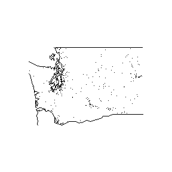

```r
fars_map_state(53, 2014)
```

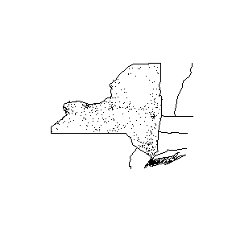

```r
fars_map_state(36, 2014)
```